# Aflevering mandag 23. september

Niklas Jespersen

21/9/2019

```r
conflict_prefer("filter", "dplyr")
```

```
## [conflicted] Will prefer dplyr::filter over any other package
```

Saving the links as to varibles, link76 and link74

```r
link76="http://data.ssb.no/api/v0/dataset/95276.json?lang=no"
link74="http://data.ssb.no/api/v0/dataset/95274.json?lang=no"
```

```r
d.temp = GET(link76)

Tabel1 = fromJSONstat(content(d.temp, "text"))

Tabl_76= Tabel1[[1]]
```

```r
d.temp2 = GET(link74)

Tabel2 = fromJSONstat(content(d.temp2, "text"))

Tabl_74= Tabel2[[1]]
```

```r
Data_hotels = rbind(Tabl_74, Tabl_76)
```

Renaming all the varible names to english Renaming all row names

```r
Data_hotels = rename(Data_hotels, "Region"="region")

Data_hotels = rename(Data_hotels, "Date"="måned")

Data_hotels = rename(Data_hotels, "Variable"="statistikkvariabel")

Data_hotels = rename(Data_hotels, "Value"="value")



Data_hotels$Date = as.Date(as.yearmon(Data_hotels$Date, "%YM%m"))



Data_hotels$Variable <- recode(Data_hotels$Variable, "Kapasitetsutnytting av senger (prosent)" = "Beds percentage capacity utilization", "Kapasitetsutnytting av rom (prosent)" =

"Rooms percentage capacity utilization", "Pris per rom (kr)" = "Price per room")
```

Filtering out data with the price

```r
Price_DATA=Data_hotels %>% filter(Value != 0) %>% filter(Variable=="Price per room")
```

I caluculate the Region average

```r
Region_average = Price_DATA %>% group_by(Region) %>% summarize(average_price=mean(Value))
```

I calculate the averege of “Hele landet”

```r
hele_landet = Price_DATA %>% filter(Region == "Hele landet")
```

```r
Mean_hele_landet = mean(hele_landet$Value)
```

I find the difference between the county average room price and the national average room price per month

```r
Dif_meanRoomPrice = Price_DATA %>% group_by(Region) %>% summarize(average_price=mean(Value)-Mean_hele_landet)
```

I find find the amount the region with the higest average price compared to the national average.

```r
L = Dif_meanRoomPrice$average_price == max(Dif_meanRoomPrice$average_price)

paste( "The higest average price compared to the national average is", Dif_meanRoomPrice[L,]$average_price, "and the region is", Dif_meanRoomPrice[L,]$Region)
```

```
## [1] "The higest average price compared to the national average is 504.231882920705 and the region is Svalbard"
```

I find find the amount the region with the lowest average price compared to the national average.

```r
M <- Dif_meanRoomPrice$average_price == min(Dif_meanRoomPrice$average_price)

paste( "The lowest average price compared to the national average is", Dif_meanRoomPrice[M,]$average_price, "and the region is", Dif_meanRoomPrice[M,]$Region)
```

```
## [1] "The lowest average price compared to the national average is -76.1299093655589 and the region is Oppland"
```

##Do the calculations above per county and per year. Identify the year and county with the highest positive and negative difference.

```r
Average_Price_By_Year_Region= Price_DATA %>% group_by(lubridate::year(Date), Region) %>% summarize(average_price_year=mean(Value))


p = Average_Price_By_Year_Region$average_price_year == max(Average_Price_By_Year_Region$average_price_year)

paste( "The higest average price is", Average_Price_By_Year_Region[p,]$average_price_year, "and the region is", Average_Price_By_Year_Region[p,]$Region, "in year", Average_Price_By_Year_Region[p,]$`lubridate::year(Date)` )
```

```
## [1] "The higest average price is 1648.28571428571 and the region is Svalbard in year 2019"
```

```r
d = Average_Price_By_Year_Region$average_price_year == min(Average_Price_By_Year_Region$average_price_year)

paste( "The lowest average price is", Average_Price_By_Year_Region[d,]$average_price_year, "and the region is", Average_Price_By_Year_Region[d,]$Region, "in year", Average_Price_By_Year_Region[d,]$`lubridate::year(Date)` )
```

```
## [1] "The lowest average price is 480.333333333333 and the region is Hedmark in year 1992"
```

Make a plot of the monthly price difference for Troms county from 1999 until today.

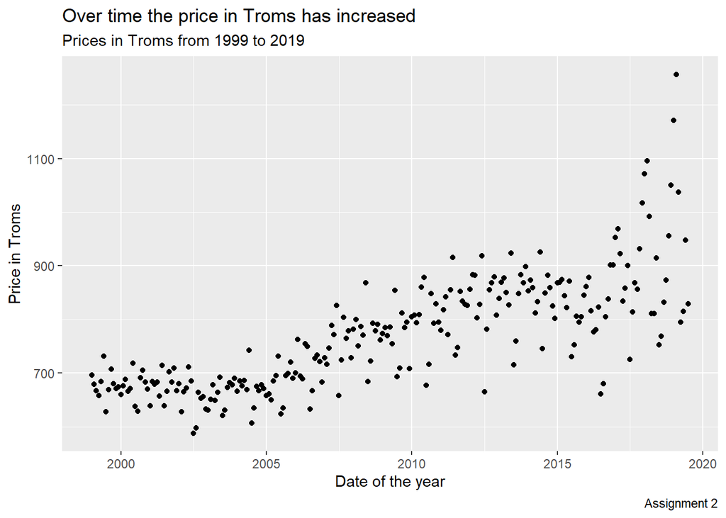

```r
Plot_Data= Price_DATA %>% filter(Region=="Troms - Romsa", Date >= "1999-01-01" & Date <= "2019-07-01")

ggplot(Plot_Data) +
  geom_point(aes(x = Date, y = Value)) +
  labs(
    x = "Date of the year",
    y = "Price in Troms",
    title = "Over time the price in Troms has increased",
    subtitle = "Prices in Troms from 1999 to 2019",
    caption = "Assignment 2")
```

Per county, is there any relationship (correlation) between room capacity and price since January 2010?

I tidy up my data

```r
Datahotel1=Data_hotels %>% filter(Value != 0)

Clean_data=na.omit(spread(Datahotel1, Variable, Value, fill = NA, convert = FALSE))
```

I find the correlations per Region

```r
Clean_data %>%
  filter(Date >= "2010-01-01" & Date <= "2019-07-01") %>%
  group_by(Region) %>%
  summarize(COR=cor(`Price per room`, `Rooms percentage capacity utilization`))
```

```
## # A tibble: 22 x 2
##    Region                    COR
##    <chr>                   <dbl>
##  1 Akershus                0.189
##  2 Aust-Agder              0.492
##  3 Buskerud               -0.203
##  4 Finnmark - Finnmárku    0.269
##  5 Hedmark                 0.379
##  6 Hele landet             0.189
##  7 Hordaland               0.659
##  8 Møre og Romsdal         0.629
##  9 Nord-Trøndelag (-2017)  0.216
## 10 Nordland                0.320
## # ... with 12 more rows
```